# Homework 2 Report

## Jana Kassem

### Setup

Read in the data with `read_csv()` and store the data as an R object named `dataset`. Check the data to make sure all of the expected observations and variables are there.

```r
library(readr)
dataset <- read_csv("maacs.csv.gz")
dataset
```

```
## # A tibble: 150 × 10
##    id         age gender  fev1   eNO cough_days  pm25   no2 mouse mouse_allergic
##    <chr>    <dbl> <chr>  <dbl> <dbl>      <dbl> <dbl> <dbl> <dbl> <chr>
##  1 fd171e2d  14.7 male    1.78   141          2  15.6  NA    2423 yes
##  2 a66fc33a  13.6 female  2.12    68          8  18.9  12.8   939 yes
##  3 fc038e68  14.5 male    2.73   210          2  17.8  NA     200 no
##  4 8e28b8c2  14.0 female  2.36    23          0  14.0  NA      NA no
##  5 b2699b54  16.6 female  3.13    18         14  17.9  31.0 10371 no
##  6 7d4f3508  16.6 female  2.59   128          0  43.8  10.6  4789 yes
##  7 3d8242a6  17.2 female  2.6     19          0  26.3  NA     760 yes
##  8 f401998a  15.5 male    3.49    26          4  39.9  32.9   264 no
##  9 357fdacb  12.7 female  2.29    17          1  27.1  25.7   419 no
## 10 2a722e16  16.0 male    2.37   134         14  64.6  18.0   187 yes
## # ℹ 140 more rows
```

## Part 1

We will first consider the relationship between FEV1 and age. In general, it is expected that as children get older (and hence, larger in size), their FEV1 values should get higher.

Consider the statement “FEV1 values in children are higher in older children relative to younger children”.

Write a function in R that takes the `dataset` object as an argument and returns `TRUE` if the statement above is true for the dataset and `FALSE` otherwise.

NOTE: In order to write this function, you will need to translate the statement above into something that can be checked with the data. There are many ways in which you can do that translation correctly and you only need to pick one way here.

NOTE: For this part, do not use any plots.

```r
library(dplyr)

fev1_age_correlation <- function(data) {
  data <- data %>%
    select(age, fev1) %>%
    na.omit()

  corr_value <- cor(data$age, data$fev1)

  # check if correlation is positive
  return(corr_value > 0)
}

fev1_age_correlation(dataset)
```

```
## [1] TRUE
```

The function below takes the dataset as input, removes missing values, and calculates the correlation between age and FEV1. It then returns TRUE if the correlation is positive and FALSE otherwise.

## Part 2

Fit a linear regression model with FEV1 as the outcome and age as a predictor.

How much does FEV1 change for a 1-year increase in the child’s age?

```r
model <- lm(fev1 ~ age, data = dataset)
summary(model)
```

```
##
## Call:
## lm(formula = fev1 ~ age, data = dataset)
##
## Residuals:
##      Min       1Q   Median       3Q      Max
## -1.51099 -0.27100  0.00196  0.23616  2.15477
##
## Coefficients:
##              Estimate Std. Error t value Pr(>|t|)
## (Intercept) -0.001199   0.134696  -0.009    0.993
## age          0.171162   0.010984  15.583   <2e-16 ***
## ---
## Signif. codes:  0 '***' 0.001 '**' 0.01 '*' 0.05 '.' 0.1 ' ' 1
##
## Residual standard error: 0.4827 on 131 degrees of freedom
##   (17 observations deleted due to missingness)
## Multiple R-squared:  0.6496, Adjusted R-squared:  0.6469
## F-statistic: 242.8 on 1 and 131 DF,  p-value: < 2.2e-16
```

Write your data analysis statement interpreting the regression model here:

For every additional year of age, a child’s FEV1 increases on average by about 0.17 units

## Part 3

Develop **three** supporting premises derived from the data that support the statement you wrote in Part 2. These can be plots, other summary statistics, or model results.

NOTE: At least one supporting premise should use a plot.

```r
library(ggplot2)

# The slope is positive and statistically significant
summary(model)
```

```
##
## Call:
## lm(formula = fev1 ~ age, data = dataset)
##
## Residuals:
##      Min       1Q   Median       3Q      Max
## -1.51099 -0.27100  0.00196  0.23616  2.15477
##
## Coefficients:
##              Estimate Std. Error t value Pr(>|t|)
## (Intercept) -0.001199   0.134696  -0.009    0.993
## age          0.171162   0.010984  15.583   <2e-16 ***
## ---
## Signif. codes:  0 '***' 0.001 '**' 0.01 '*' 0.05 '.' 0.1 ' ' 1
##
## Residual standard error: 0.4827 on 131 degrees of freedom
##   (17 observations deleted due to missingness)
## Multiple R-squared:  0.6496, Adjusted R-squared:  0.6469
## F-statistic: 242.8 on 1 and 131 DF,  p-value: < 2.2e-16
```

```r
# Older kids have higher average FEV1 versus younger kids
med_age <- median(dataset$age, na.rm = TRUE)
mean_younger <- mean(dataset$fev1[dataset$age < med_age], na.rm = TRUE)
mean_older   <- mean(dataset$fev1[dataset$age >= med_age], na.rm = TRUE)
cat("The mean FEV1 for younger children (below median age) is", round(mean_younger, 2), "\n")
```

```
## The mean FEV1 for younger children (below median age) is 1.33
```

```r
cat("The mean FEV1 for older children (at or above median age) is", round(mean_older, 2), "\n")
```

```
## The mean FEV1 for older children (at or above median age) is 2.54
```

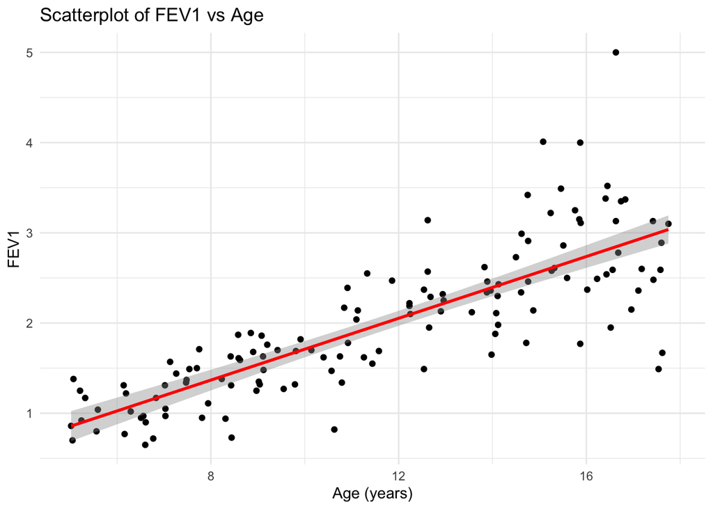

```r
# Scatterplot with regression line
ggplot(dataset, aes(x = age, y = fev1)) +
  geom_point() +
  geom_smooth(method = "lm", color = "red") +
  labs(
    title = "Scatterplot of FEV1 vs Age",
    x = "Age (years)",
    y = "FEV1"
  ) +
  theme_minimal()
```

Write the three supporting premise statements here:

1. The estimated slope for age is positive and statistically significant
2. The mean FEV1 for older children (above median age) is higher than the mean FEV1 for younger children (below median age).
3. A scatter plot of FEV1 vs. age with a fitted regression line shows an upward trend.

## Part 4

For each of the supporting premises above, write a function that takes the `dataset` object as an argument and returns `TRUE` if the supporting premise statement above is true for the dataset and `FALSE` otherwise.

For statements involving plots, instead of returning `TRUE` or `FALSE`, you function should do two things:

1. Produce the plot that is used in the statement
2. Produce a hypothetical version of the plot in the event that the statement is true. This can be done using simulated data or by simply hand drawing a plot.

```r
## Function for supporting premise statement 1

premise1 <- function(data, alpha = 0.05) {
  df = subset(data, !is.na(age) & !is.na(fev1))
  model = lm(fev1 ~ age, data = df)
  sum = summary(model)
  slope = coef(model)[["age"]]
  pval = coef(sum)["age", "Pr(>|t|)"]
  slope > 0 && !is.na(pval) && pval < alpha
}

premise1(dataset)
```

```
## [1] TRUE
```

The regression output shows that the slope for age is positive with a p-value less than 0.05. This indicates that as age increases, FEV1 tends to increase significantly, supporting the statement.

```r
## Function for supporting premise statement 2

premise2 <- function(data) {
  df = subset(data, !is.na(age) & !is.na(fev1))
  # Split into older and younger kids
  med_age = median(df$age)
  young = df$fev1[df$age < med_age]
  old = df$fev1[df$age >= med_age]
  # Compare group means
  # Return true if the mean of older kids is higher
  mean(old, na.rm = TRUE) > mean(young, na.rm = TRUE)
}

premise2(dataset)
```

```
## [1] TRUE
```

The results show that older children have a higher mean FEV1 compared to younger children, which provides further evidence for the positive association between age and lung function.

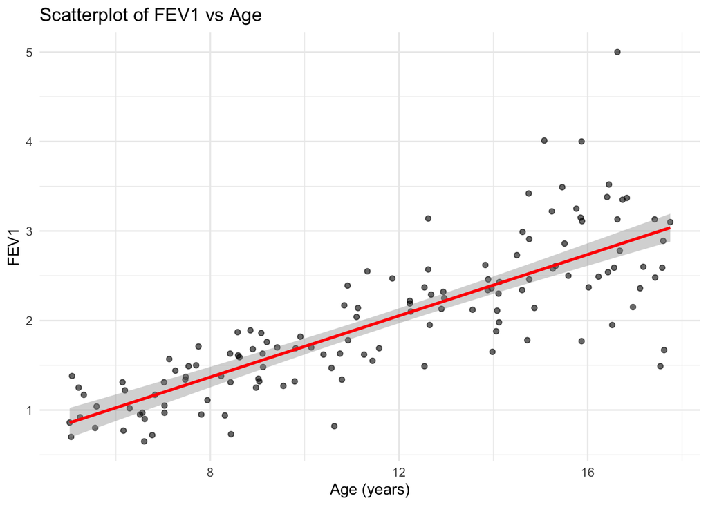

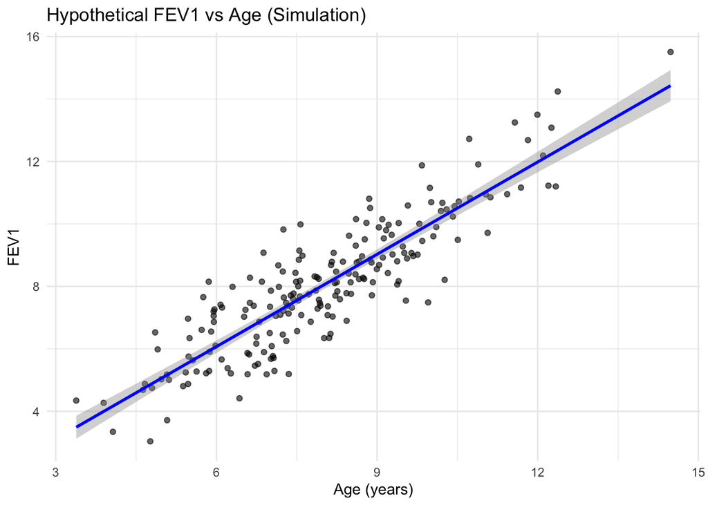

```r
## Function for supporting premise statement 3
library(ggplot2)
library(tibble)

premise3 <- function(data) {

  df <- subset(data, !is.na(age) & !is.na(fev1))

  # Actual scatterplot
  actual <- ggplot(df, aes(x = age, y = fev1)) +
    geom_point(alpha = 0.6) +
    geom_smooth(method = "lm", color = "red") +
    labs(title = "Scatterplot of FEV1 vs Age",
      x = "Age (years)",
      y = "FEV1") +
    theme_minimal()
  print(actual)

  # Hypothetical upward-trend
  set.seed(123)
  x <- rnorm(200, mean = 8, sd = 2)
  y <- x + rnorm(200, mean = 0, sd = 1)

  hypothetical <- tibble(age = x, fev1 = y) |>
    ggplot(aes(x = age, y = fev1)) +
    geom_point(alpha = 0.6) +
    geom_smooth(method = "lm", color = "blue") +
    labs(
      title = "Hypothetical FEV1 vs Age (Simulation)",
      x = "Age (years)",
      y = "FEV1"
    ) +
    theme_minimal()
  print(hypothetical)
}

premise3(dataset)
```

The scatterplot shows an upward-sloping red regression line through the data points, which visually supports the finding that FEV1 tends to increase as children get older. This graphical evidence complements the model results and summary statistics from the previous premises.

## Part 5

Describe one alternative to the primary statement “FEV1 values in children are higher in older children relative to younger children”.

Create a fault tree for the alternative outcome describing how the alternative outcome could be realized in the data even if the primary statement were true.

Your fault tree should be created as a separate image and does not need to be created in R. Upload the image of the fault tree to Canvas.

FEV1 values are higher in younger children rather than older children.